# MPDW Pertemuan 2

Vita Rizkyana Anggraeni_G1401211065

## Pemanggilan *Packages*

```r
library(rio)
library(dplyr)
library(TTR)
library(forecast)
library(lmtest) #digunakan untuk uji formal pendeteksian autokorelasi
library(orcutt) #untuk membuat model regresi Cochrane-Orcutt
library(HoRM) #untuk membuat model regresi Hildreth-Lu
```

## Input Data

```r
data <- import("https://raw.githubusercontent.com/vitaarizkyana/PraktikumMPDW/main/Minggu%202/Data%20Pertemuan%202.csv")
data$V1 = seq(from = 1, to = 72, by = 1)
data = data[,-c(4,10,11,12)]
data <- data.frame(data)
View(data)
summary(data)
```

```
##        V1             AQI              CO             no2
##  Min.   : 1.00   Min.   :19.00   Min.   :191.9   Min.   :0.01556
##  1st Qu.:18.75   1st Qu.:25.00   1st Qu.:197.4   1st Qu.:0.03799
##  Median :36.50   Median :27.00   Median :200.3   Median :0.04552
##  Mean   :36.50   Mean   :26.18   Mean   :200.1   Mean   :0.04200
##  3rd Qu.:54.25   3rd Qu.:28.00   3rd Qu.:203.6   3rd Qu.:0.05020
##  Max.   :72.00   Max.   :32.00   Max.   :208.6   Max.   :0.06091
##        o3             pm10             pm25            so2
##  Min.   :41.48   Min.   : 6.687   Min.   :1.633   Min.   :0.2831
##  1st Qu.:53.64   1st Qu.: 7.865   1st Qu.:1.829   1st Qu.:0.3204
##  Median :57.22   Median : 8.914   Median :2.202   Median :0.3725
##  Mean   :56.57   Mean   : 9.115   Mean   :2.295   Mean   :0.3634
##  3rd Qu.:60.08   3rd Qu.:10.275   3rd Qu.:2.522   3rd Qu.:0.3958
##  Max.   :68.66   Max.   :12.846   Max.   :5.637   Max.   :0.4545
```

```r
str(data)
```

```
## 'data.frame':    72 obs. of  8 variables:
##  $ V1  : num  1 2 3 4 5 6 7 8 9 10 ...
##  $ AQI : num  30.2 28.2 26.6 25 26 26 26 24 23 24 ...
##  $ CO  : num  199 198 199 202 205 ...
##  $ no2 : num  0.0469 0.0465 0.0469 0.0482 0.0489 ...
##  $ o3  : num  55.8 54.9 54.6 55.1 55.8 ...
##  $ pm10: num  10.5 10.7 11.2 11.1 10.4 ...
##  $ pm25: num  5.64 4.62 3.52 2.23 1.98 ...
##  $ so2 : num  0.387 0.41 0.402 0.376 0.339 ...
```

```r
n <- 72
```

## Cek Korelasi Peubah Bebas terhadap Peubah Respon

```r
library(corrplot)
korelasi <- cor(data)
korelasi
```

```
##               V1         AQI          CO        no2          o3        pm10
## V1    1.00000000 -0.45387002 -0.62078757 -0.4710941 -0.38710594 -0.01967075
## AQI  -0.45387002  1.00000000  0.79763320  0.7376547  0.97359901  0.08257568
## CO   -0.62078757  0.79763320  1.00000000  0.6520228  0.82919809 -0.09598578
## no2  -0.47109406  0.73765472  0.65202279  1.0000000  0.73204188  0.25652368
## o3   -0.38710594  0.97359901  0.82919809  0.7320419  1.00000000  0.03381079
## pm10 -0.01967075  0.08257568 -0.09598578  0.2565237  0.03381079  1.00000000
## pm25  0.16599284 -0.34665524 -0.58291511 -0.3588091 -0.52197786  0.26848271
## so2   0.50412173 -0.74247813 -0.79872002 -0.5859130 -0.78562485 -0.04779446
##            pm25         so2
## V1    0.1659928  0.50412173
## AQI  -0.3466552 -0.74247813
## CO   -0.5829151 -0.79872002
## no2  -0.3588091 -0.58591304
## o3   -0.5219779 -0.78562485
## pm10  0.2684827 -0.04779446
## pm25  1.0000000  0.67434283
## so2   0.6743428  1.00000000
```

y:`AQI` x1,x2,x3,x4: `o3`, `CO`, `no2`, dan `so2`

```r
y <- data$AQI
x0 <- rep(1,72)
x1 <- data$o3
x2 <- data$CO
x3 <- data$no2
x4 <- data$so2
data <- data.frame(y, x0, x1, x2, x3, x4)
data
```

```
##       y x0       x1       x2         x3        x4
## 1  30.2  1 55.78995 198.6027 0.04685717 0.3874302
## 2  28.2  1 54.93164 197.6013 0.04645554 0.4097819
## 3  26.6  1 54.64554 198.6027 0.04685717 0.4023313
## 4  25.0  1 55.07469 201.9405 0.04819594 0.3762543
## 5  26.0  1 55.78995 205.2784 0.04886533 0.3390014
## 6  26.0  1 56.50520 208.6163 0.05020411 0.3129244
## 7  26.0  1 55.78995 208.6163 0.05020411 0.3129244
## 8  24.0  1 52.92892 205.2784 0.05020411 0.3427267
## 9  23.0  1 50.06790 200.2716 0.04685717 0.3948808
## 10 24.0  1 51.49841 196.9338 0.04417961 0.4284084
## 11 25.0  1 53.64418 198.6027 0.04284084 0.4284084
## 12 26.0  1 55.78995 200.2716 0.04049798 0.3986061
## 13 27.0  1 59.36623 203.6095 0.04016329 0.3501773
## 14 29.0  1 62.22725 205.2784 0.03882451 0.3166497
```

[output cut: 58 more lines]

```r
X <- cbind(x0,x1,x2,x3)
X
```

```
##       x0       x1       x2         x3
##  [1,]  1 55.78995 198.6027 0.04685717
##  [2,]  1 54.93164 197.6013 0.04645554
##  [3,]  1 54.64554 198.6027 0.04685717
##  [4,]  1 55.07469 201.9405 0.04819594
##  [5,]  1 55.78995 205.2784 0.04886533
##  [6,]  1 56.50520 208.6163 0.05020411
##  [7,]  1 55.78995 208.6163 0.05020411
##  [8,]  1 52.92892 205.2784 0.05020411
##  [9,]  1 50.06790 200.2716 0.04685717
## [10,]  1 51.49841 196.9338 0.04417961
## [11,]  1 53.64418 198.6027 0.04284084
## [12,]  1 55.78995 200.2716 0.04049798
## [13,]  1 59.36623 203.6095 0.04016329
## [14,]  1 62.22725 205.2784 0.03882451
```

[output cut: 58 more lines]

## Plot Time Series

```r
#Membentuk objek time series
data.ts<-ts(data$y)
data.ts
```

```
## Time Series:
## Start = 1
## End = 72
## Frequency = 1
##  [1] 30.2 28.2 26.6 25.0 26.0 26.0 26.0 24.0 23.0 24.0 25.0 26.0 27.0 29.0 29.0
## [16] 29.0 29.0 28.0 27.0 27.0 27.0 27.0 27.0 27.0 27.0 28.0 29.0 31.0 31.0 32.0
## [31] 32.0 31.0 31.0 30.0 30.0 29.0 27.0 26.0 25.0 25.0 24.0 24.0 25.0 25.0 25.0
## [46] 26.0 26.0 27.0 27.0 27.0 27.0 28.0 28.0 27.0 27.0 26.0 25.0 23.0 22.0 21.0
## [61] 20.0 19.0 19.0 20.0 21.0 21.0 21.0 22.0 24.0 26.0 27.0 28.0
```

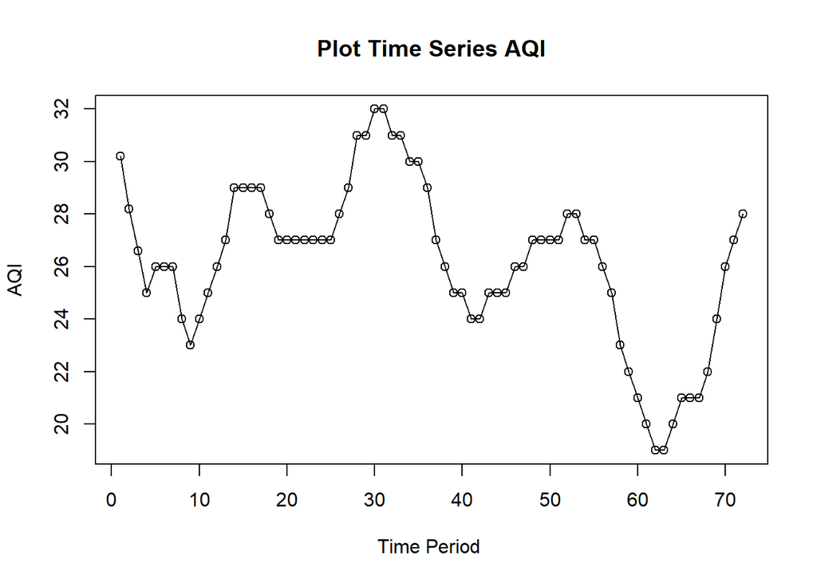

```r
#Membuat plot time series
ts.plot(data.ts, xlab="Time Period ", ylab="AQI", main= "Plot Time Series AQI")
points(data.ts)
```

# Model regresi

```r
modelreg <- lm(y~x1+x2+x3+x4, data = data)
summary(modelreg)
```

```
##
## Call:
## lm(formula = y ~ x1 + x2 + x3 + x4, data = data)
##
## Residuals:
##     Min      1Q  Median      3Q     Max
## -0.6611 -0.3375 -0.0954  0.1579  4.2057
##
## Coefficients:
##              Estimate Std. Error t value Pr(>|t|)
## (Intercept) -0.580921   7.420153  -0.078    0.938
## x1           0.468551   0.027505  17.035   <2e-16 ***
## x2          -0.008867   0.036557  -0.243    0.809
## x3          15.717244  11.205342   1.403    0.165
## x4           3.766816   3.316734   1.136    0.260
## ---
## Signif. codes:  0 '***' 0.001 '**' 0.01 '*' 0.05 '.' 0.1 ' ' 1
##
## Residual standard error: 0.6985 on 67 degrees of freedom
## Multiple R-squared:  0.9507, Adjusted R-squared:  0.9477
## F-statistic: 322.7 on 4 and 67 DF,  p-value: < 2.2e-16
```

Model regresi yang diperoleh :
$$AQI_i=-0.580921+
0.468551x1_i-0.008867x2_i+15.717244x32_i+3.766816x4_i$$

Uji F $p-value < \alpha= 0.05 \ (Tolak H_0)$ Artinya, cukup bukti untuk menyatakan bahwa ada minimal satu peubah penjelas yang berpengaruh signifikan terhadap nilai `AQI`pada taraf nyata 5%.

Diperoleh nilai $R^2= 0.9507$ Artinya, keragaman nilai AQI dapat dijelaskan oleh model yang telah dibentuk sebesar 95.07%. Nilai ini menunjukkan hasil yang bagus. Untuk mendapatkan hasil terbaik, perlu dilakukan pengujian asumsi terhadap model.

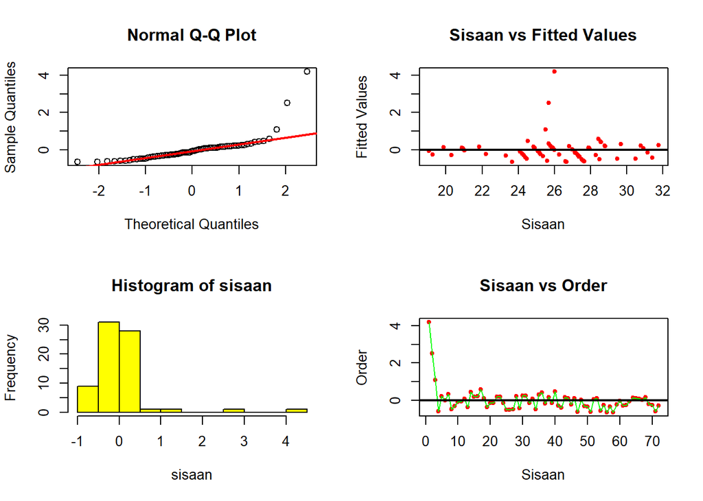

```r
#Sisaan dan Fitted Value
sisaan <- residuals(modelreg)
fitValue <- predict(modelreg)

#Diagnostik dengan eksploratif
par(mfrow = c(2,2))
qqnorm(sisaan) #normal qq plot
qqline(sisaan, col = "red", lwd = 2) #normal qq plot
plot(fitValue, sisaan, col = "red", pch = 20, xlab = "Sisaan", ylab = "Fitted Values", main = "Sisaan vs Fitted Values")
abline(a = 0, b = 0, lwd = 2)
hist(sisaan, col = "yellow")
plot(seq(1,72,1), sisaan, col = "red", pch = 20, xlab = "Sisaan", ylab = "Order", main = "Sisaan vs Order")
lines(seq(1,72,1), sisaan, col = "green")
abline(a = 0, b = 0, lwd = 2)
```

```r
#Melihat Sisaan Menyebar Normal/Tidak
#H0: sisaan mengikuti sebaran normal
#H1: sisaan tidak mengikuti sebaran normal
shapiro.test(sisaan)
```

```
##
##  Shapiro-Wilk normality test
##
## data:  sisaan
## W = 0.61134, p-value = 1.642e-12
```

```r
ks.test(sisaan, "pnorm", mean=mean(sisaan), sd=sd(sisaan))
```

```
##
##  Exact one-sample Kolmogorov-Smirnov test
##
## data:  sisaan
## D = 0.23664, p-value = 0.0004962
## alternative hypothesis: two-sided
```

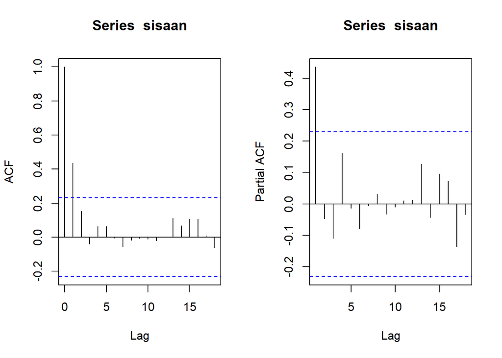

```r
#ACF dan PACF identifikasi autokorelasi
par(mfrow = c(1,2))
acf(sisaan)
pacf(sisaan)
```

```r
#garis acf atau pacf yg melewati garis biru mengidentifikasi autokorelasi

#Deteksi autokorelasi dengan uji-Durbin Watson
#H0: tidak ada autokorelasi
#H1: ada autokorelasi
dwtest(modelreg)
```

```
##
##  Durbin-Watson test
##
## data:  modelreg
## DW = 0.58426, p-value = 2.368e-14
## alternative hypothesis: true autocorrelation is greater than 0
```

Berdasarkan hasil DW Test, didapatkan nilai $DW = 0.58426$ dan *p-value* = $2.368*10^-14$. Nilai $p-value < \alpha= 0.05 \ (Tolak H_0)$ Artinya, cukup bukti untuk menyatakan bahwa terdapat autokorelasi sehingga diperlukan penangan autokorelasi. Penanganan yang akan digunakan menggunakan dua metode, yaitu Cochrane-Orcutt dan Hildret-Lu.